# DETECTR 049 Luminometer Data

Note that everything is plotted on a log10(x) and flexible log10(y) scale, meaning the axis changes with every plot. 6 kinetic reads for 10s interval will equate to a 1 minute integration time, summed and displayed here. The LOWEST concentration was read first, rather than the highest concentration as was done in previous experiments.

# Experiments performed (in the following order)

1. Before and after bleach clean ENLITEN samples on water
2. NANCY DREW LOD with AMP no kinase and ENLITEN + AMP standards in buffer
3. ATP Standards in buffer

## ENLITEN ATP H20 Control Before and After 1hr Bleach Soak

- 6 reads, 2s delay after injection, 10s integration time, total of 1 minute
- Recommended flush performed before first H20 read
- 2% bleach loaded into injectors, then left for 1hr
- H20 primed 10X
- Recommended flush performed and then ENLITEN reagent primed

### Conclusion

Running bleach and performing an extra flush leads to 3X reduction in background from H20 in ENLITEN kit.

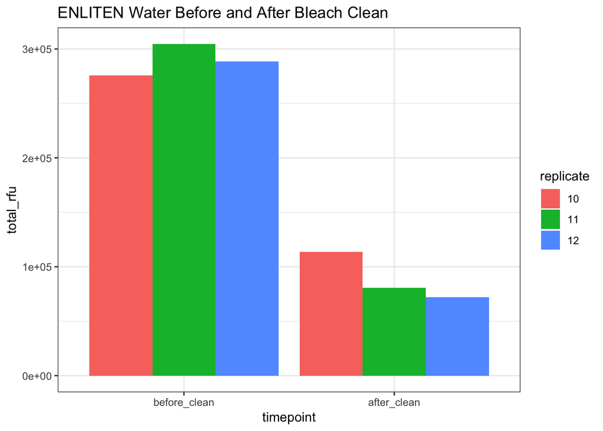

## NANCY DREW ENLITEN AMP No Kinase Experiment (AMP standards from 1e-10 to 1e-16 moles)

### Experimental Execution

- AMP Detection Reagent was 1X NEBuffer 2.1 + the correct amount of Reagent II
- For all samples, added Reagent 1 and incubated for 1 hour. I staggered this by 6 minutes.
- I staggered the addition of AMP Detection Reagent 2 for each row, using a multichannel to add the correct reagent every 6 minutes starting from the end of the incubation of Reagent I.
- Injection plate reader reads by row, so for a 1 minute read of 6 wells, it takes 6 minutes to do one row
- Each concentration was done in triplicate
- AMP standards contain no ATP and are diluted in 0.5X NEBuffer 2.1 and 1X NEBuffer 4.
- No reporter control was read first, followed by concentrations from low to high.

### Reads

- 2s delay after injection, 10 s integration time, and 6 reads were taken

### Plots

- All 6 reads were summed for the total_rfu plotted in all three graphs

### Conclusions

AMP standards display a lot of variability. The 0 value (in buffer) is similar to the water. Perhaps the ATP levels drop as more samples are performed, explaining the lower signal for 1e-16 to 1e-13 moles. The NANCY DREW samples display a concentration dependent signal, illustrating that it works. However, it is only really sensitive down to 1.25e-16 mol of input DNA. There is also a much higher background (~10X higher) for the NANCY DREW samples than for the AMP standards, indicating that other reagents are contributing to signal. The no reporter control (which contained 1.25e-13 mol of input target DNA) also confusingly shows a high signal.

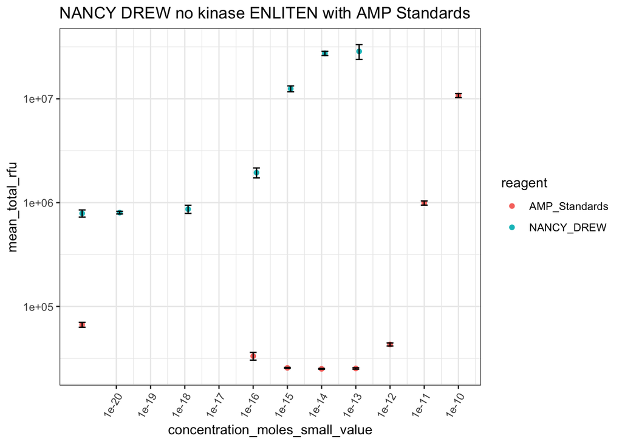

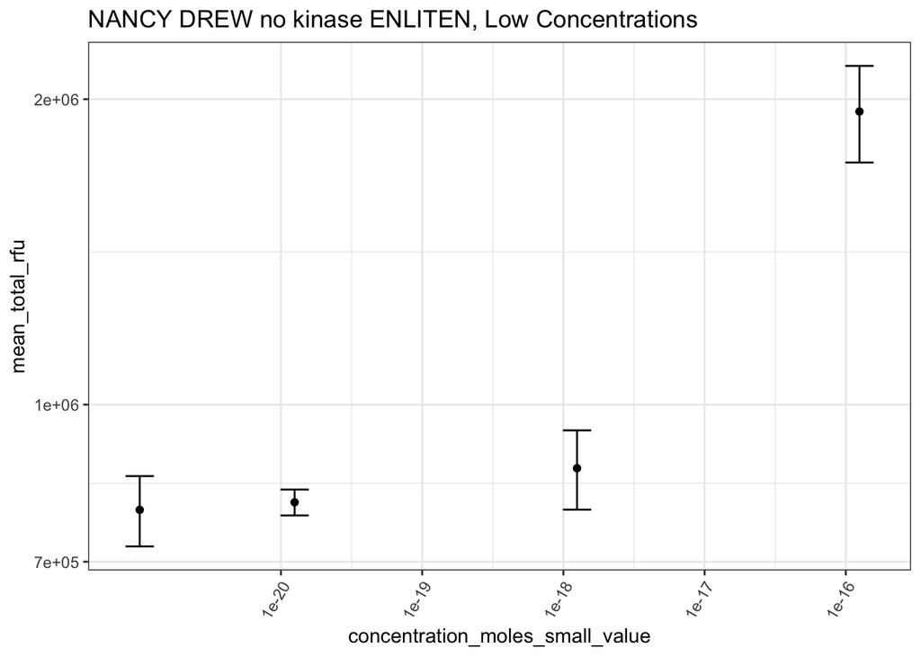

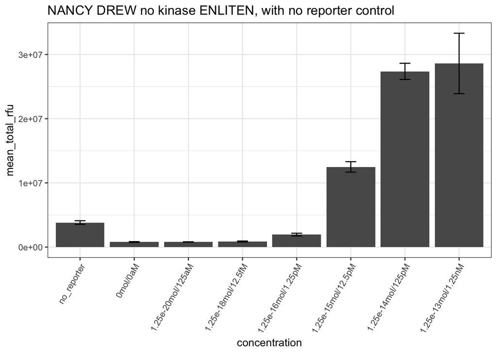

## ENLITEN ATP Standards from 1E-11 to 1E-17 moles

- 6 reads, 2s delay after injection, 10s integration time, total of 1 minute
- Standards were diluted in a 0.5X NEBuffer 2.1 and 1X NEBuffer 4

### Conclusion

The standards look similar to what we have seen in the past, but buffer seems to have a LOWER background (~4X lower), perhaps because this experiment was done at the end of the day after all other samples. There is an outlier in the 1e-15 concentration, which impacts the regression, but all other replicates look fine for that concentration. High concentration relationship look very linear. There is minimal difference between 1e-16 and 1e-17 but both are higher than 0. Since data is only taken for 1 minute, it is hard to see any kinetics, but it does appear that the signal doesn’t drop too much in that time frame.

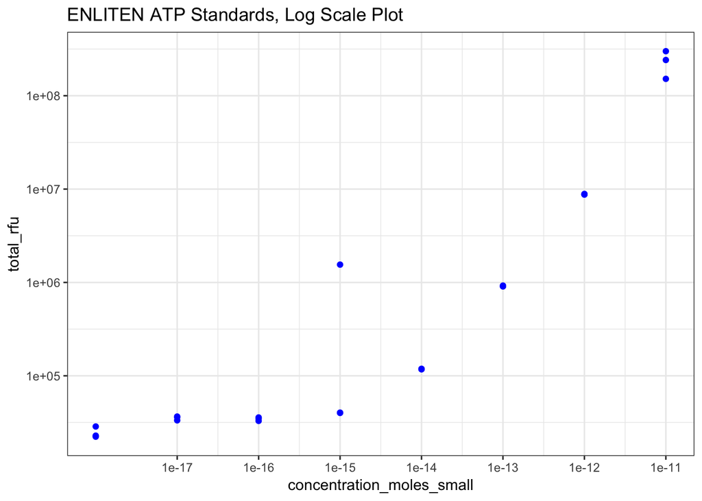

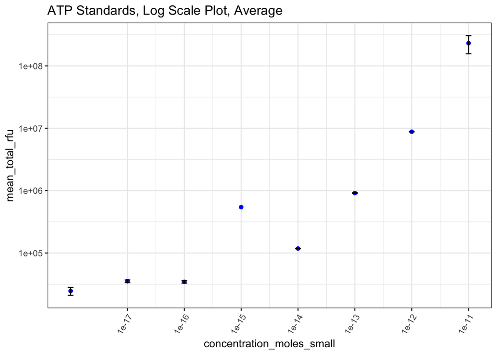

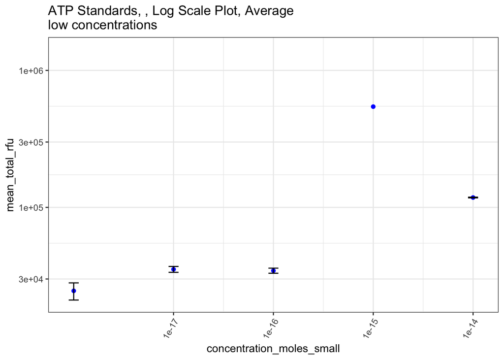

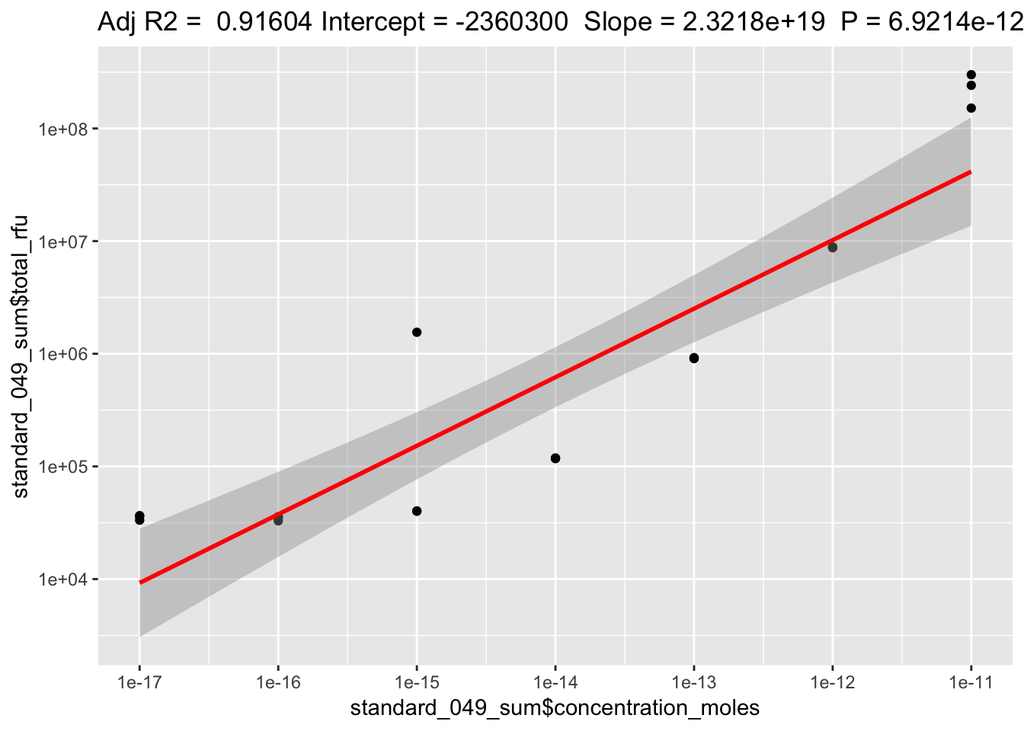

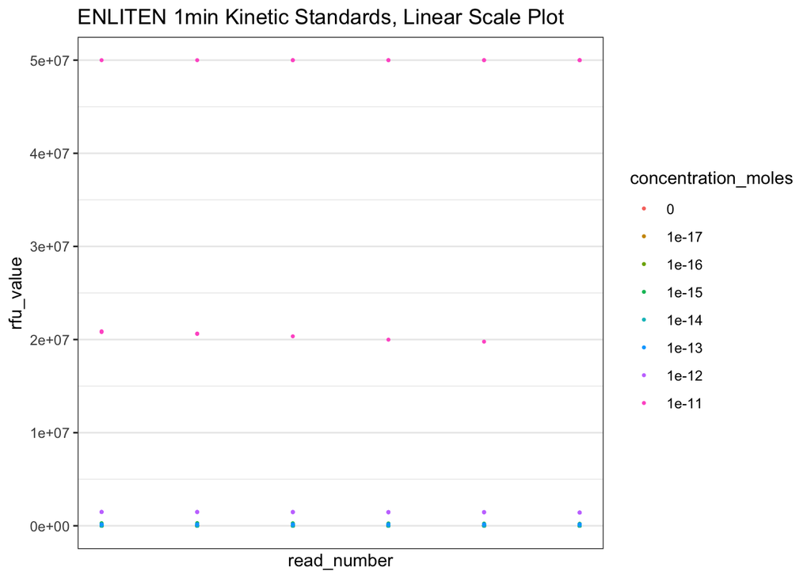

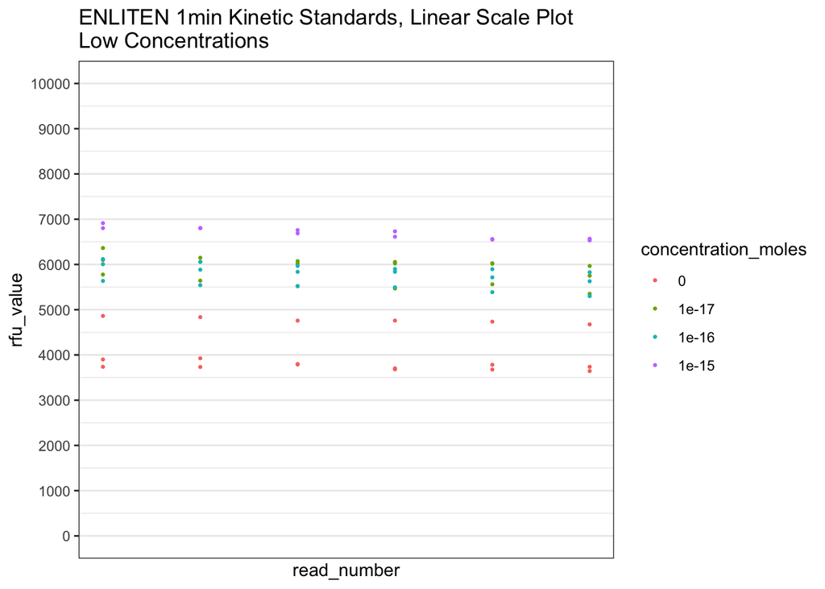